# Practice8

### 직접 구현한 Linear Regression 알고리즘 정의

```r
Linear_regression <- function(df, feature_col, actual_col, t0, t1, alpha, iter_num){
  # (1) Hypothesis 설정
  h <- function(feature_col, t0, t1){
    t0 + t1 * df[, feature_col]
  }

  # (2) Cost 함수 설정
  cost_J <- function(df, feature_col, actual_col, t0, t1){
    1/(2*nrow(df)) * sum( (h(feature_col, t0, t1) - df[, actual_col]) ** 2 )
  }

  # (3) 처음에 설정한 theta0, theta1을 통해서 나온 Cost 함수 결과로 output_df 틀 만들기
  output_df <- data.frame(iter = 0, t0 = t0, t1 = t1, alpha = alpha,
                          cost = cost_J(df, feature_col, actual_col, t0, t1))

  # (4) iteration 횟수만큼 학습하면서 output_df에 결과 누적시키기
  for (i in 1:iter_num){
    derivative0 <- alpha * mean( h(feature_col, t0, t1) - df[, actual_col] )
    derivative1 <- alpha * mean( (h(feature_col, t0, t1) - df[, actual_col]) * df[, feature_col] )

    t0 <- t0 - derivative0
    t1 <- t1 - derivative1

    output_df <- rbind(output_df, c(i, t0, t1, alpha, cost_J(df, feature_col, actual_col, t0, t1)))

    # (5) Cost 함수의 감소 폭이 10e-4 보다 작으면 iteration 횟수와 상관 없이 학습 중단
    if (output_df$cost[nrow(output_df) - 1] - output_df$cost[nrow(output_df)] <= 10e-4){break}
  }

  return (output_df)
}
```

단변량 변수의 Linear Regression 알고리즘의 학습 과정은 다음과 같다.

1. 가설(h)과 비용함수(J)를 설정하도록 한다.
2. 비용함수는 1/2m * sum( (예측값 - 실제값) ** 2 )로 계산하도록 한다.
3. 임의의 theta0과 theta1을 설정하고, 값을 대입하여 비용함수 값을 계산한다.
4. 궁극적으로는 이 비용함수를 최소화 시키도록 하는 theta0과 theta1를 찾도록 한다.
5. 이를 위해서 현재의 theta0과 theta1 각각에서 접선의 기울기를 계산하여 해당 값들을 업데이트해준다.
6. 바뀐 theta0과 theta1을 활용하여 비용함수 값을 계산하고, 이 값을 최소화 할때까지 반복한다.

## 1. alpha 값을 변경하여 학습 과정 확인하기

```r
path <- 'https://raw.githubusercontent.com/Paul-scpark/Data_Mining_Practicum/main/data/'
exData <- read.csv(paste0(path, 'ex1data1.txt'), header = F, col.names = c('pop', 'profit'))

head(exData)
```

```
##      pop  profit
## 1 6.1101 17.5920
## 2 5.5277  9.1302
## 3 8.5186 13.6620
## 4 7.0032 11.8540
## 5 5.8598  6.8233
## 6 8.3829 11.8860
```

주어진 데이터를 부르고, head 부분만 확인해보도록 한다.

```r
# alpha_vec <- c(0.001, 0.005, 0.01, 0.05, 0.1, 1)
alpha_vec <- c(0.0001, 0.001, 0.005, 0.01)
alpha_list <- list()
for (alpha in alpha_vec){
  alpha_list[[paste0('alpha_', alpha)]] <- Linear_regression(exData, 'pop', 'profit', 0, 1, alpha, 1500)
}

total_df <- data.frame()
for (i in alpha_list){
  total_df <- rbind(total_df, i[, c('iter', 'cost', 'alpha')])
}

table(total_df$alpha)
```

```
##
## 0.0001  0.001  0.005   0.01
##   1501   1501   1501   1501
```

```r
head(total_df)
```

```
##   iter     cost  alpha
## 1    0 7.445856 0.0001
## 2    1 7.419584 0.0001
## 3    2 7.393743 0.0001
## 4    3 7.368323 0.0001
## 5    4 7.343320 0.0001
## 6    5 7.318724 0.0001
```

위에서 정의했던 linear_regression 함수를 활용하여 alpha 값을 바꾸면서 결과 데이터프레임을 list에 할당한다.

그리고 나서는 alpha 값에 따른 결과를 확인하기 위하여 alpha에 따른 iter와 cost 값을 추려서 total_df에 할당한다.

그 후에 table과 head 함수로 각 데이터의 개수와 값들이 잘 들어갔는지 확인해보도록 한다.

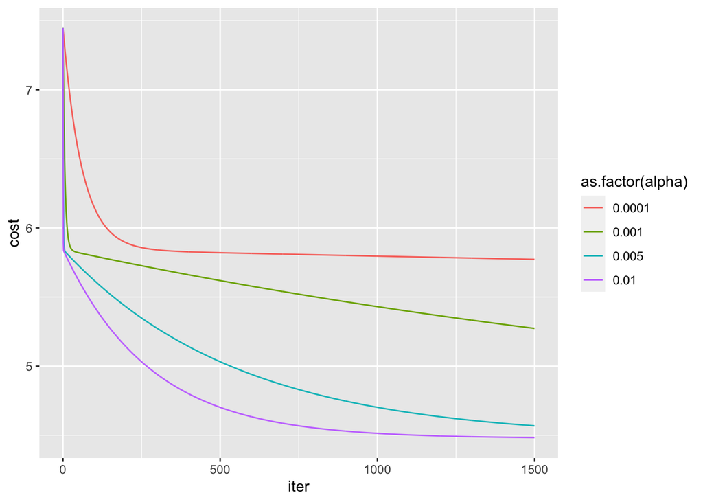

```r
total_df %>%
  filter(cost != Inf) %>%
  ggplot(aes(x = iter, y = cost, color = as.factor(alpha))) +
  geom_line()
```

```r
total_df %>%
  filter(iter == max(iter))
```

```
##   iter     cost  alpha
## 1 1500 5.772728 0.0001
## 2 1500 5.273371 0.0010
## 3 1500 4.568423 0.0050
## 4 1500 4.483071 0.0100
```

그리고 나서 최종적으로 alpha 값에 따라서 iter 횟수를 x축으로, cost 값을 y축으로 하는 그래프를 그린다.

Learning rate를 의미하는 alpha 값이 0.01 보다 커지는 경우에는 너무 학습률이 크기 때문에 cost 함수의 값이 더 커지는 결과가 나왔다.

따라서 0.001, 0.005, 0.01 이라는 alpha 값으로 결과를 확인해보았다.

전반적으로 결과를 보면, 학습률이 가장 작았던 0.0001의 경우에는 반복 횟수가 약 250번 정도 일때부터 cost가 떨어지지 않고 있다.

학습률이 0.001인 경우에는 1500번을 반복했음에도 여전히 어느 일정 수준에 수렴하지 못하는 형태를 볼 수 있다.

한편, 0.005나 0.01의 학습률은 1500번 정도의 반복을 통해서 점차적으로 Cost 함수가 줄고 있음을 확인할 수 있다.

alpha 값에 따라서 1500번 학습한 cost 결과를 출력해보면, 위와 같은 결과를 확인할 수 있다.

## 2. Cost 함수의 결과값의 감소폭이 둔화되는 경우에 학습을 중단하기

```r
alpha_vec <- c(0.0001, 0.001, 0.005, 0.01, 0.05)
alpha_list <- list()
for (alpha in alpha_vec){
  alpha_list[[paste0('alpha_', alpha)]] <- Linear_regression(exData, 'pop', 'profit', 0, 1, alpha, 1500)
}

total_df <- data.frame()
for (i in alpha_list){
  total_df <- rbind(total_df, i[, c('iter', 'cost', 'alpha')])
}

table(total_df$alpha)
```

```
##
## 0.0001  0.001  0.005   0.01   0.05
##    203     39    503    444      2
```

```r
head(total_df)
```

```
##   iter     cost  alpha
## 1    0 7.445856 0.0001
## 2    1 7.419584 0.0001
## 3    2 7.393743 0.0001
## 4    3 7.368323 0.0001
## 5    4 7.343320 0.0001
## 6    5 7.318724 0.0001
```

이번에는 Cost 함수의 감소폭이 10e-4 (충분히 작은 값) 보다 더 작은 경우에는 iteration 횟수와 상관 없이 학습을 중단하도록 한다.

이를 통해서 결과를 확인해보면, 기존 1번에서는 모든 alpha에 대하여 데이터 개수가 1501개였지만, 지금은 모두 다른 것을 볼 수 있다.

앞서 언급했던 것처럼 학습률이 0.005나 0.01 정도일때, 어느 정도 학습하면 Cost 함수의 값이 수렴하는 것을 유추해볼 수 있다.

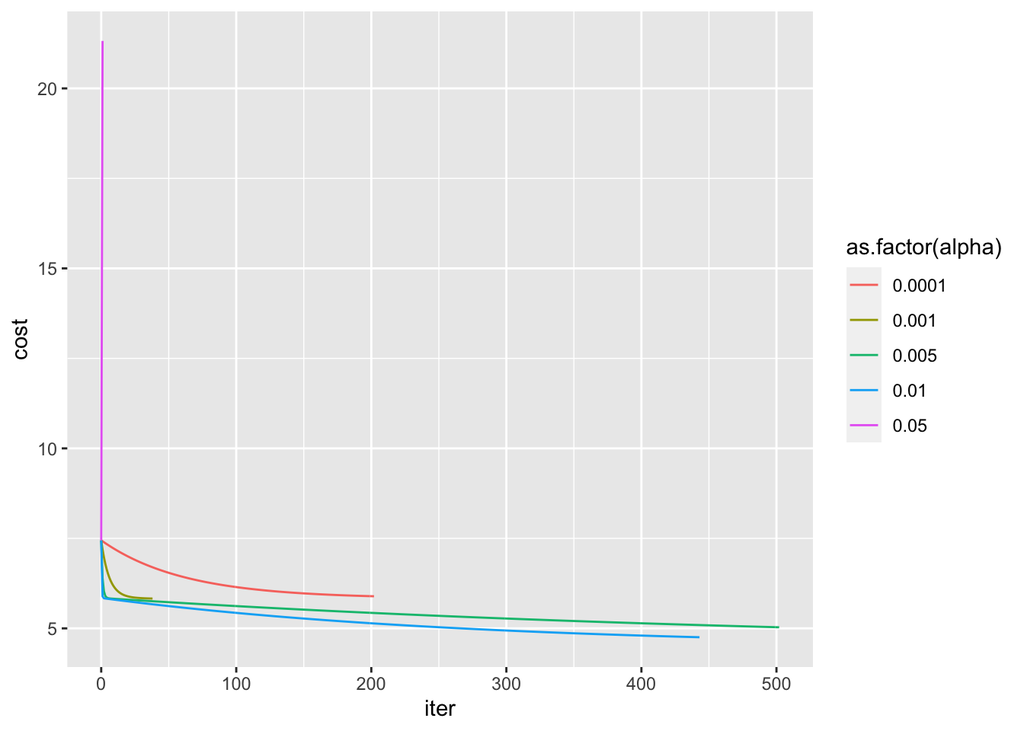

```r
total_df %>%
  filter(cost != Inf) %>%
  ggplot(aes(x = iter, y = cost, color = as.factor(alpha))) +
  geom_line()
```

```r
total_df %>%
  group_by(alpha) %>%
  filter(iter == max(iter))
```

```
## # A tibble: 5 × 3
## # Groups:   alpha [5]
##    iter  cost  alpha
##   <dbl> <dbl>  <dbl>
## 1   202  5.89 0.0001
## 2    38  5.83 0.001
## 3   502  5.03 0.005
## 4   443  4.75 0.01
## 5     1 21.3  0.05
```

이를 그래프로 표현하면 위와 같음을 확인할 수 있다.

전반적으로 0.005, 0.01 정도의 학습률이 충분히 학습이 되면서 cost 함수의 결과값도 꾸준히 감소하는 것을 확인할 수 있다.

학습률이 너무 컸던 0.05의 경우에는 Cost 값이 감소하지 않은 상태에서 학습이 중단되었다.

또한 학습률이 너무 작았던 0.0001의 경우에는 200번 정도 학습한 경우 그 감소폭이 너무 둔화되어 학습이 중단되었다.

따라서 이 결과에서도 1번과 동일하게 0.005나 0.01 정도의 alpha 값일때 학습이 잘 이뤄진다는 것을 확인할 수 있다.

## 3. 다변량 변수의 Linear Regression

```r
exData2 <- read.csv(paste0(path, 'ex1data2.txt'), header = F, col.names = c('size', 'num_bedroom', 'price'))
summary(exData2)
```

```
##       size       num_bedroom       price
##  Min.   : 852   Min.   :1.00   Min.   :169900
##  1st Qu.:1432   1st Qu.:3.00   1st Qu.:249900
##  Median :1888   Median :3.00   Median :299900
##  Mean   :2001   Mean   :3.17   Mean   :340413
##  3rd Qu.:2269   3rd Qu.:4.00   3rd Qu.:384450
##  Max.   :4478   Max.   :5.00   Max.   :699900
```

이번에는 단변량이 아닌 2개 이상의 변수를 활용한 다변량 Linear Regression에 대해서 알아보도록 한다.

이를 위해서 집 값을 예측하는 데이터셋을 불러오고, 집의 크기와 방의 개수라는 2개 변수를 활용해보도록 한다.

```r
# normalization
exData2 <- exData2 %>%
  mutate(size.norm = (size - mean(size)) / sd(size),
         num_bedroom.norm = (num_bedroom - mean(num_bedroom)) / sd(num_bedroom))

featureDF <- exData2 %>%
  mutate(bias = 1) %>%
  select(bias, ends_with('norm')) %>%
  as.matrix()

label_vector <- exData2$price
```

가장 먼저는 각 변수들의 scale이 다르기 때문에 평균과 표준편차를 활용하여 정규화를 실시해주도록 한다.

그리고 정규화된 변수에 bias를 새로운 열로 하여 featureDF라는 매트릭스를 만들어준다.

그 후에는 모델의 target 변수인 집 값을 의미하는 price 데이터를 label_vector로 미리 할당해준다.

```r
regression <- function(n, num_iter, alpha){
  # (1) Hypothesis 설정
  h <- function(x, theta_vector){ # x is feature vector
    theta_vector %*% x            # inner product of two vectors
  }

  # (2) Cost 함수 설정
  cost_J <- function(theta_vector){
    v <- as.matrix(featureDF) %*% theta_vector - label_vector
    (t(v) %*% v / (2*nrow(featureDF)))[1, 1]
    # 1 / 2 * mean(v ** 2)
  }

  # (3) 처음에 설정한 theta_vector를 통해 나온 Cost 함수 결과로 output_df 틀 만들기
  theta_vector <- c(0, 0, 0)

  output_df <- data.frame(iter = 0,
                       t0 = theta_vector[1],
                       t1 = theta_vector[2],
                       t2 = theta_vector[3],
                       cost = cost_J(theta_vector),
                       alpha = alpha)

  # (4) iteration 횟수만큼 학습하면서 output_df에 결과 누적시키기
  for (i in 1:num_iter){
    v <- featureDF %*% theta_vector - label_vector
    theta_update <- alpha / n * t(featureDF) %*% v
    theta_vector <- theta_vector - theta_update
    output_df <- rbind(output_df, c(i, theta_vector, cost_J(theta_vector), alpha))
  }

  return (output_df)
}
```

그리고 여러 개의 변수들을 활용하여 Linear Regerssion을 할 수 있도록 새로운 함수를 만들어주도록 한다.

```r
alpha_vec <- c(0.0001, 0.001, 0.005, 0.01, 0.05, 0.1, 1)
alpha_list <- list()
for (alpha in alpha_vec){
  alpha_list[[paste0('alpha_', alpha)]] <- regression(nrow(featureDF), 1500, alpha)
}

total_df <- data.frame()
for (i in alpha_list){
  total_df <- rbind(total_df, i[, c('iter', 'cost', 'alpha')])
}

table(total_df$alpha)
```

```
##
## 0.0001  0.001  0.005   0.01   0.05    0.1      1
##   1501   1501   1501   1501   1501   1501   1501
```

```r
head(total_df)
```

```
##   iter        cost  alpha
## 1    0 65591548106 0.0001
## 2    1 65578572965 0.0001
## 3    2 65565600536 0.0001
## 4    3 65552630819 0.0001
## 5    4 65539663815 0.0001
## 6    5 65526699522 0.0001
```

위에서 정의한 regression 함수를 활용하여 alpha의 값을 바꿔가면서 list에 각 데이터들의 결과를 할당한다.

그리고 나서는 iter, cost, alpha만 추려서 rbind를 하여 각 alpha 별로의 결과를 하나의 데이터프레임으로 만들어준다.

이를 table 함수를 통해서 각 alpha 값에 대하여 데이터들이 몇 개씩 있는지 확인할 수 있고, head로 윗부분만 확인해본다.

최종적으로는 이를 그래프로 표현하여 각 alpha 값에 대하여 cost 값의 변화 추이를 확인해보도록 한다.

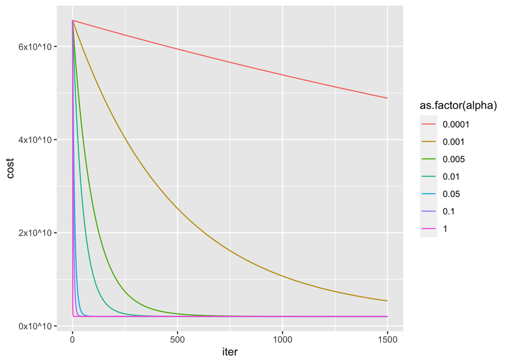

```r
label_ko_num <- function(num){
  ko_num <- function(x){
    new_num <- x %/% 10**10
    return(paste(new_num, 'x10^10', sep = ''))
  }
  return(sapply(num, ko_num))
}

total_df %>% ggplot(aes(x = iter, y = cost, color = as.factor(alpha))) +
  geom_line() +
  scale_y_continuous(labels = label_ko_num)
```

```r
total_df %>%
  filter(iter == max(iter))
```

```
##   iter        cost  alpha
## 1 1500 48877681525 0.0001
## 2 1500  5372521769 0.0010
## 3 1500  2045598272 0.0050
## 4 1500  2043283577 0.0100
## 5 1500  2043280051 0.0500
## 6 1500  2043280051 0.1000
## 7 1500  2043280051 1.0000
```

alpha 값에 따른 cost 값 변화 그래프는 위와 같음을 확인할 수 있다.

한편, 학습률이 큰 1, 0.1, 0.05와 같은 경우에는 iter 횟수가 100번도 채 되지 않아서 특정 값에 수렴하는 것을 확인할 수 있다.

## 4. 직접 구현한 알고리즘을 활용하여 부동산 가격 예측

```r
real_estate <- read_excel('Real_estate_valuation.xlsx')

# Simple Preprocessing
real_estate <- real_estate[, c(-1, -2, -6, -7)]
colnames(real_estate) <- c('House_age', 'Distance_MRT', 'Number_of_stores', 'Price')

real_estate <- real_estate %>%
  mutate(House_age = (House_age - mean(House_age)) / sd(House_age),
         Distance_MRT = (Distance_MRT - mean(Distance_MRT)) / sd(Distance_MRT),
         Number_of_stores = (Number_of_stores - mean(Number_of_stores)) / sd(Number_of_stores))

head(real_estate)
```

```
## # A tibble: 6 × 4
##   House_age Distance_MRT Number_of_stores Price
##       <dbl>        <dbl>            <dbl> <dbl>
## 1     1.25        -0.792            2.00   37.9
## 2     0.157       -0.616            1.67   42.2
## 3    -0.387       -0.414            0.308  47.3
## 4    -0.387       -0.414            0.308  54.8
## 5    -1.12        -0.549            0.308  43.1
## 6    -0.932        0.865           -0.371  32.1
```

이번에는 위에서 구현했던 Linear Regression 함수를 직접 부동산 데이터셋에 적용해보도록 한다.

주어진 데이터를 부르고, 학습에 사용할 ‘House_age’, ‘Distance_MRT’, ‘Number_of_stores’, ‘Price’ 변수들만 추리도록 한다.

그리고 나서 각 변수들의 scale이 모두 다르기 때문에 정규화까지 진행하고, head 함수로 결과를 확인해본다.

```r
# Splitting train, test dataset
train_idx <- sample(1:nrow(real_estate), size = 0.8 * nrow(real_estate), replace = F)
test_idx <- setdiff(1:nrow(real_estate), train_idx)

train_df <- real_estate[train_idx, ]
test_df <- real_estate[test_idx, ]

dim(train_df)
```

```
## [1] 331   4
```

```r
dim(test_df)
```

```
## [1] 83  4
```

```r
featureDF <- train_df %>%
  mutate(bias = 1) %>%
  select(-Price) %>%
  as.matrix()

label_vector <- train_df$Price
```

그 후에는 모델을 직접 학습하고, 결과를 확인해야 하기 때문에 train과 test 데이터셋으로 나눠주도록 한다.

sample 함수를 통해서 임의로 선택한 80%를 train으로, 나머지 20%를 test로 할당해주도록 한다.

결과를 확인해보면, 기존 414개 데이터 중에서 약 80%에 해당하는 331개의 데이터가 train으로, 나머지 20%의 83개가 test로 할당되었다.

그 후에는 모델을 학습하기 위해서 bias 열을 추가해주고, target 변수인 price는 label_vector로 따로 빼주도록 한다.

```r
regression <- function(feature_df, label, n, num_iter, alpha){
  # (1) Hypothesis 설정
  h <- function(x, theta_vector){ # x is feature vector
    theta_vector %*% x            # inner product of two vectors
  }

  # (2) Cost 함수 설정
  cost_J <- function(theta_vector){
    v <- as.matrix(feature_df) %*% theta_vector - label
    (t(v) %*% v / (2*nrow(feature_df)))[1, 1]
    # 1 / 2 * mean(v ** 2)
  }

  # (3) feature_df의 열의 개수만큼 theta_vector를 정의해주고, Cost 함수 결과로 output_df 틀 만들기
  theta_vector <- rep(0, ncol(feature_df))

  theta_df <- as.data.frame(t(as.data.frame(theta_vector)))
  rownames(theta_df) <- 1
  colnames(theta_df) <- str_replace(colnames(theta_df), 'V', 't')

  output_df <- data.frame(iter = 0, cost = cost_J(theta_vector), alpha = alpha)
  output_df <- cbind(output_df, theta_df)

  # (4) iteration 횟수만큼 학습하면서 output_df에 결과 누적시키기
  for (i in 1:num_iter){
    v <- feature_df %*% theta_vector - label
    theta_update <- alpha / n * t(feature_df) %*% v
    theta_vector <- theta_vector - theta_update
    output_df <- rbind(output_df, c(i, cost_J(theta_vector), alpha, theta_vector))

  # (5) Cost 함수의 감소 폭이 10e-4 보다 작으면 iteration 횟수와 상관 없이 학습 중단
  if (output_df$cost[nrow(output_df) - 1] - output_df$cost[nrow(output_df)] <= 10e-4){break}
  }

  return (output_df)
}
```

위에서 정의했던 알고리즘을 조금 수정 및 보완하도록 한다. feature의 개수가 달라지다보니, theta의 개수가 달라질 수 밖에 없다.

위 알고리즘에서는 theta를 3개로 고정했다보니, 오류가 있어서 feature의 개수만큼 theta_vector를 할당해주도록 했다.

또한 이를 통해서 output_df도 theta_vector의 개수만큼 값이 들어가도록 했다.

이번에는 학습하면서 cost 값이 일정 수준에서 감소하지 않으면, 학습을 중단하도록 했다.

```r
alpha_vec <- c(0.001, 0.005, 0.01, 0.05, 0.1, 1)
alpha_list <- list()
for (alpha in alpha_vec){
  alpha_list[[paste0('alpha_', alpha)]] <- regression(featureDF, label_vector, nrow(featureDF), 1500, alpha)
}

total_df <- data.frame()
for (i in alpha_list){
  total_df <- rbind(total_df, i)
}

table(total_df$alpha)
```

```
##
## 0.001 0.005  0.01  0.05   0.1     1
##  1501   903   490   118    64    13
```

위의 예시와 동일하게 0.001, 0.005, 0.01, 0.05, 0.1, 1 까지의 alpha 값으로 회귀 모델을 만들어서 결과를 저장했다.

alpha 값에 따라서 중간에 cost의 감소폭이 작아서 학습이 일찍 중단된 결과도 확인할 수 있다.

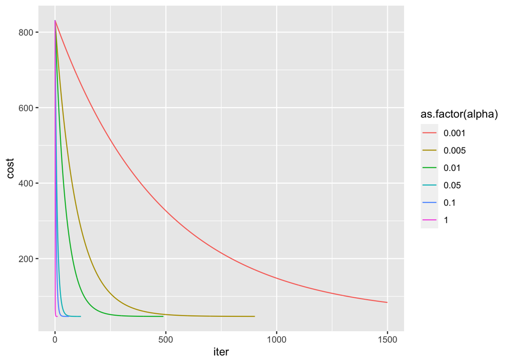

```r
total_df %>%
  filter(cost != Inf) %>%
  ggplot(aes(x = iter, y = cost, color = as.factor(alpha))) +
  geom_line()
```

이 결과를 그래프로 표현하면 위와 같음을 확인할 수 있다.

학습률이 너무 작았던 0.001의 경우에는 1500번을 수행했음에도 cost 값이 수렴하지 못한 것을 확인할 수 있다.

0.005나 0.01 정도의 학습률이 충분히 학습이 되면서 cost 값도 일정 수준에 수렴하는 것을 볼 수 있다.

```r
total_df %>%
  group_by(alpha) %>%
  filter(iter == max(iter))
```

```
## # A tibble: 6 × 7
## # Groups:   alpha [6]
##    iter  cost alpha    t1    t2    t3    t4
##   <dbl> <dbl> <dbl> <dbl> <dbl> <dbl> <dbl>
## 1  1500  83.8 0.001 -2.27 -5.49  4.35  29.7
## 2   902  46.9 0.005 -2.79 -6.53  4.19  37.8
## 3   489  46.8 0.01  -2.79 -6.57  4.15  38.0
## 4   117  46.8 0.05  -2.79 -6.66  4.07  38.1
## 5    63  46.7 0.1   -2.79 -6.69  4.04  38.2
## 6    12  46.7 1     -2.77 -6.83  3.88  38.2
```

```r
theta <- total_df %>%
  filter(alpha == 0.01) %>%
  filter(iter == max(iter)) %>%
  select(t1, t2, t3, t4)

theta
```

```
##             t1        t2       t3       t4
## 4902 -2.793775 -6.571735 4.152001 37.95766
```

각 alpha 값 별로 iter의 최댓값을 추려서 결과를 확인해보면, 다음과 같음을 알 수 있다.

이와 같은 과정을 수행했던 이유는 처음에 정의한 hypothesis에 들어갈 각 변수와 theta 값들을 찾기 위함이었다.

즉, t1, t2, t3, t4의 값을 통해서 각 변수들과 곱해서 실제 price에 대한 예측 price 값을 계산해볼 수 있다는 것이다.

위 결과를 통해서 cost가 충분히 작고, 학습도 적당히 됐다고 판단되는 alpha가 0.01 정도 일때의 theta를 활용해보고자 한다.

이 theta 값들에 대해서 해석하면, 위에서 학습한 데이터들의 순서대로의 계수를 뜻한다고 할 수 있다.

즉, t1부터 t3까지는 ‘House_age’, ‘Distance_MRT’, ’Number_of_stores’의 계수를 뜻하고, t4는 bias 즉, y절편을 뜻한다고 할 수 있다.

```r
df <- test_df %>%
  mutate(bias = 1) %>%
  select(-Price)

test_df <- test_df %>%
  mutate(price_predict = as.matrix(df) %*% unlist(theta, use.names = FALSE))

head(test_df)
```

```
## # A tibble: 6 × 5
##   House_age Distance_MRT Number_of_stores Price price_predict[,1]
##       <dbl>        <dbl>            <dbl> <dbl>             <dbl>
## 1    0.157        -0.616           1.67    42.2              48.5
## 2   -0.387        -0.414           0.308   54.8              43.0
## 3   -1.12         -0.549           0.308   43.1              46.0
## 4    0.0165        0.554          -0.371   22.1              32.7
## 5   -1.00         -0.787           1.67    58.1              52.8
## 6    0.236         1.10           -0.0320  23.8              30.0
```

```r
output1 <- rmse(test_df$Price, test_df$price_predict)
output1
```

```
## [1] 7.062905
```

이를 통해 test 데이터로부터 theta 값을 활용하여 price_predict 값을 계산해보도록 한다.

위 결과를 head 함수로 출력해보았고, 최종적으로는 실제값과 예측값에 대한 RMSE를 계산해보았다.

그 결과는 약 7.06 정도의 RMSE가 나온 것을 확인할 수 있다.

## 5. Linear Regression 내장 함수 lm을 통한 결과 확인

```r
# train_df <- train_df[, c(-5)]
test_df <- test_df[, c(-5)]

model <- lm(Price ~ ., data = train_df)
test_df <- test_df %>%
  mutate(price_predict = predict(model, newdata = test_df))

head(test_df)
```

```
## # A tibble: 6 × 5
##   House_age Distance_MRT Number_of_stores Price price_predict
##       <dbl>        <dbl>            <dbl> <dbl>         <dbl>
## 1    0.157        -0.616           1.67    42.2          48.5
## 2   -0.387        -0.414           0.308   54.8          43.3
## 3   -1.12         -0.549           0.308   43.1          46.3
## 4    0.0165        0.554          -0.371   22.1          33.0
## 5   -1.00         -0.787           1.67    58.1          52.9
## 6    0.236         1.10           -0.0320  23.8          29.9
```

```r
output2 <- rmse(test_df$Price, test_df$price_predict)
output2
```

```
## [1] 7.104248
```

이번에는 R에서 내장되어 있는 Linear Regression 함수인 lm 함수를 이용하여 결과를 확인해보고자 한다.

확실히 위 과정보다는 간편하고, 단순한 것을 직관적으로 확인할 수 있었다.

위 데이터와 동일한 trian과 test를 활용하고, target 변수인 Price에 대하여 전체 변수들을 학습해주도록 한다.

그렇게 만들어진 model에 test 데이터에 대하여 predict한 결과를 price_predict로 할당해주도록 한다.

4번과 동일하게 test 데이터에서의 실제값과 예측값에 대한 RMSE를 확인해보면, 약 7.1 정도의 값이 나오는 것을 볼 수 있다.

이러한 과정을 통해서 자체적으로 구현한 4번과 lm 함수를 사용했던 5번의 결과가 거의 유사함을 확인할 수 있었다.

```r
theta_test <- t(as.data.frame(model$coefficients))
rownames(theta_test) <- 'lm_function'

theta <- theta[, c('t4', 't1', 't2', 't3')]
rownames(theta) <- 'Own_algorithm'
colnames(theta) <- colnames(theta_test)

cbind(rbind(theta_test, theta), RMSE = rbind(output1, output2))
```

[output not shown]

실제 각 모델들에 대하여 theta 값을 확인해보면 위와 같음을 볼 수 있다.

RMSE 자체가 유사했던 것처럼 theta 값들 역시도 큰 차이 없이 두 모델에서 거의 유사하다는 것을 다시 확인할 수 있다.